# turtle_path_practice

A turtle starts at the star in the middle. By dragging markers along a grid, she makes 5 line segments. The first segment is red, and then she changes color after each turn, following the progression of a rainbow.

The distance between adjacent dots is 1 unit. The grid is oriented with North pointing up and East pointing right.

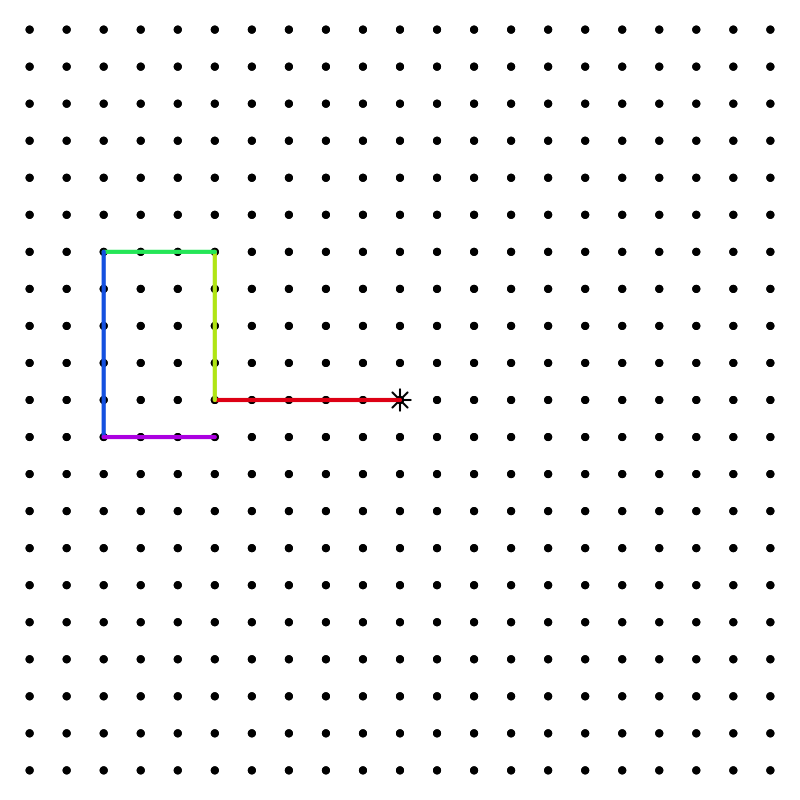

Describe the path taken by the turtle.

- West 5
- North 4
- West 3
- South 5
- East 3

A turtle starts at the star in the middle. By dragging markers along a grid, she makes 5 line segments. The first segment is red, and then she changes color after each turn, following the progression of a rainbow.

The distance between adjacent dots is 1 unit. The grid is oriented with North pointing up and East pointing right.

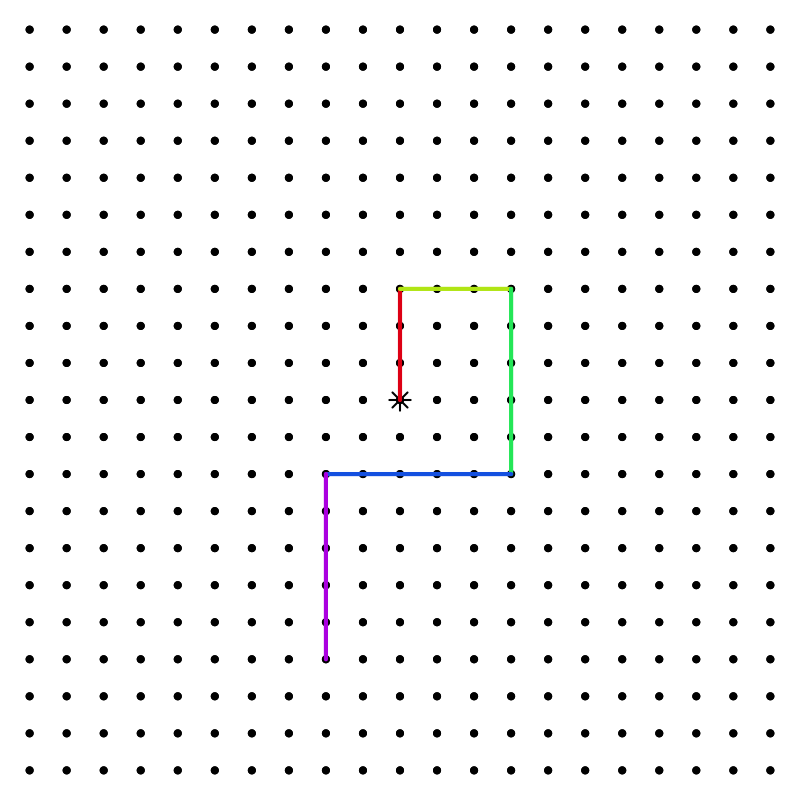

Describe the path taken by the turtle.

- North 3
- East 3
- South 5
- West 5
- South 5

A turtle starts at the star in the middle. By dragging markers along a grid, she makes 5 line segments. The first segment is red, and then she changes color after each turn, following the progression of a rainbow.

The distance between adjacent dots is 1 unit. The grid is oriented with North pointing up and East pointing right.

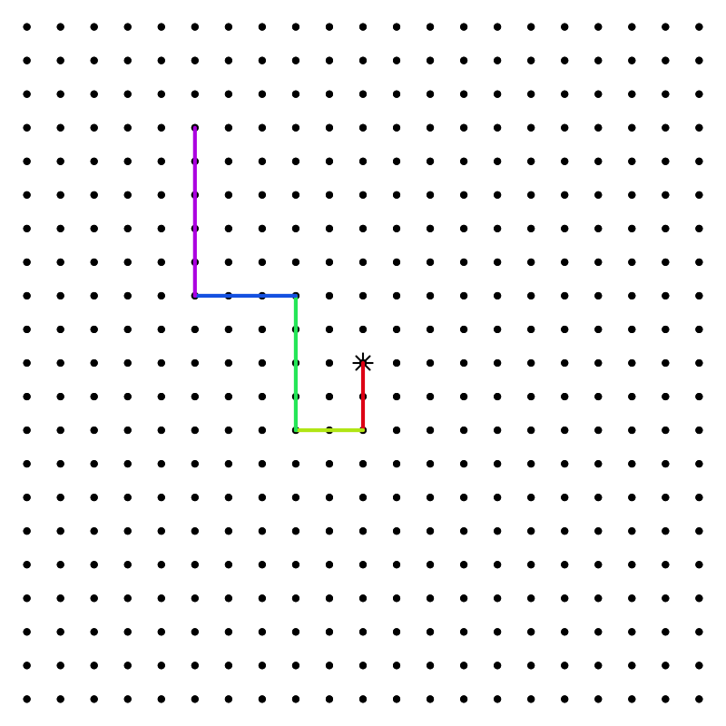

Describe the path taken by the turtle.

- South 2
- West 2
- North 4
- West 3
- North 5

A turtle starts at the star in the middle. By dragging markers along a grid, she makes 5 line segments. The first segment is red, and then she changes color after each turn, following the progression of a rainbow.

The distance between adjacent dots is 1 unit. The grid is oriented with North pointing up and East pointing right.

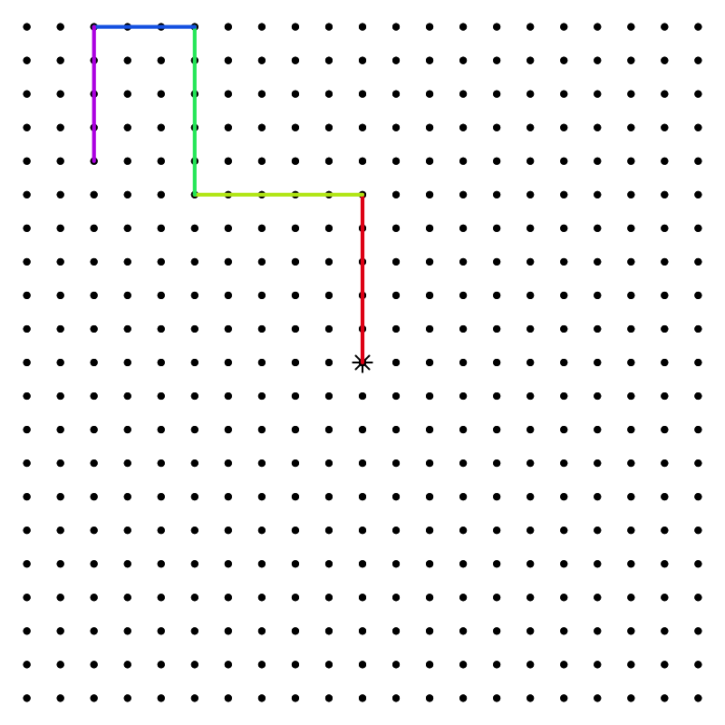

Describe the path taken by the turtle.

- North 5
- West 5
- North 5
- West 3
- South 4

A turtle starts at the star in the middle. By dragging markers along a grid, she makes 5 line segments. The first segment is red, and then she changes color after each turn, following the progression of a rainbow.

The distance between adjacent dots is 1 unit. The grid is oriented with North pointing up and East pointing right.

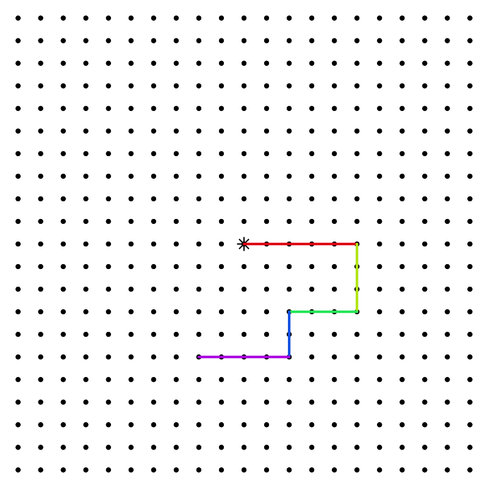

Describe the path taken by the turtle.

- East 5
- South 3
- West 3
- South 2
- West 4

A turtle starts at the star in the middle. By dragging markers along a grid, she makes 5 line segments. The first segment is red, and then she changes color after each turn, following the progression of a rainbow.

The distance between adjacent dots is 1 unit. The grid is oriented with North pointing up and East pointing right.

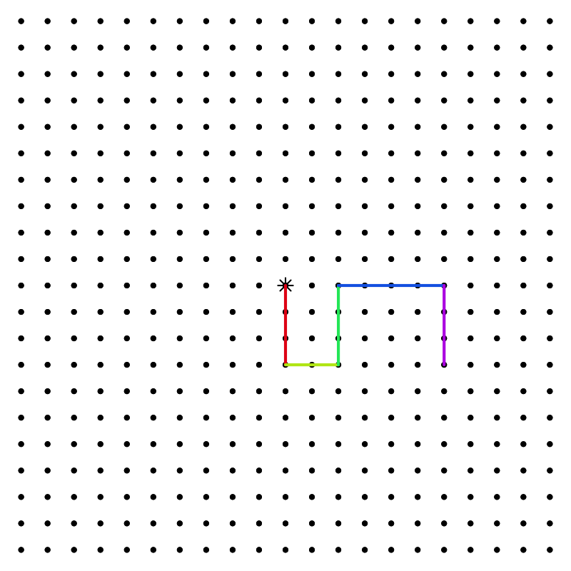

Describe the path taken by the turtle.

- South 3
- East 2
- North 3
- East 4
- South 3

A turtle starts at the star in the middle. By dragging markers along a grid, she makes 5 line segments. The first segment is red, and then she changes color after each turn, following the progression of a rainbow.

The distance between adjacent dots is 1 unit. The grid is oriented with North pointing up and East pointing right.

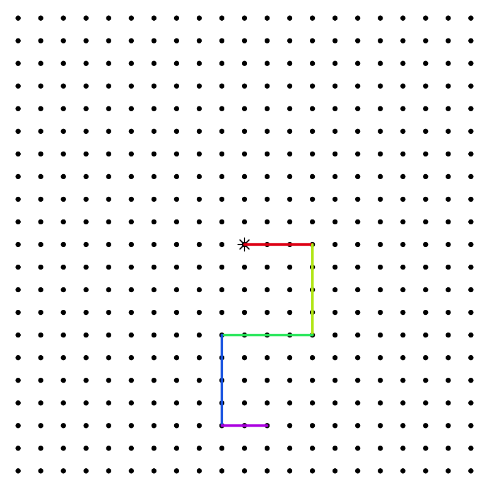

Describe the path taken by the turtle.

- East 3
- South 4
- West 4
- South 4
- East 2

A turtle starts at the star in the middle. By dragging markers along a grid, she makes 5 line segments. The first segment is red, and then she changes color after each turn, following the progression of a rainbow.

The distance between adjacent dots is 1 unit. The grid is oriented with North pointing up and East pointing right.

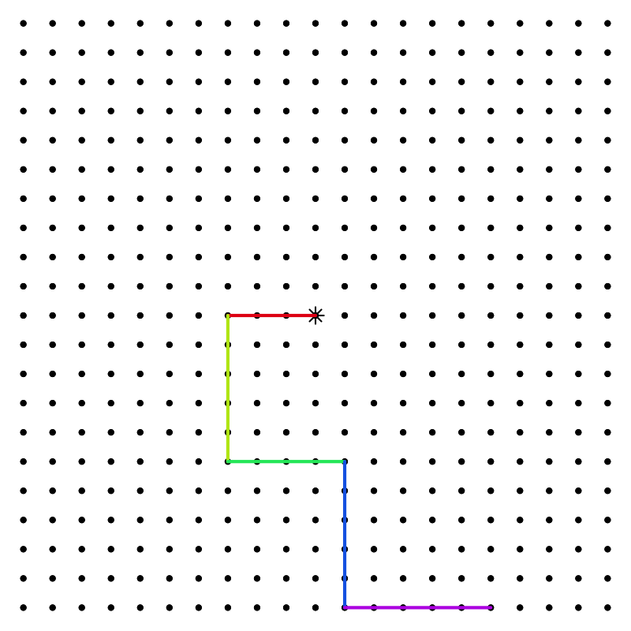

Describe the path taken by the turtle.

- West 3
- South 5
- East 4
- South 5
- East 5

A turtle starts at the star in the middle. By dragging markers along a grid, she makes 5 line segments. The first segment is red, and then she changes color after each turn, following the progression of a rainbow.

The distance between adjacent dots is 1 unit. The grid is oriented with North pointing up and East pointing right.

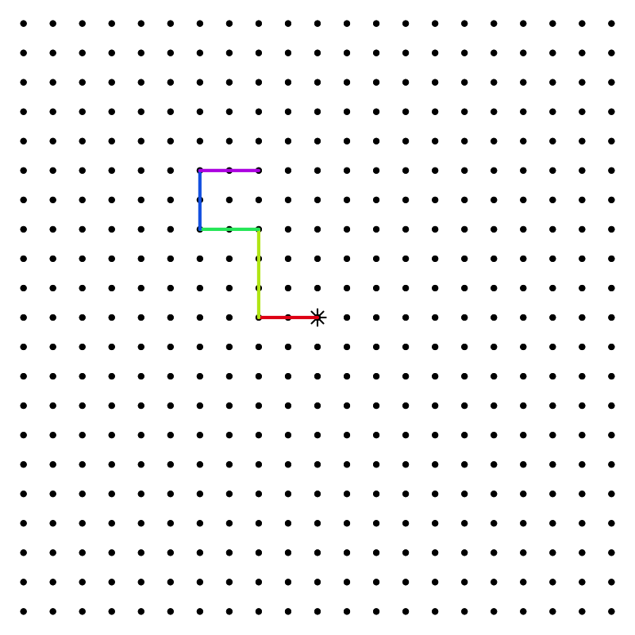

Describe the path taken by the turtle.

- West 2
- North 3
- West 2
- North 2
- East 2

A turtle starts at the star in the middle. By dragging markers along a grid, she makes 5 line segments. The first segment is red, and then she changes color after each turn, following the progression of a rainbow.

The distance between adjacent dots is 1 unit. The grid is oriented with North pointing up and East pointing right.

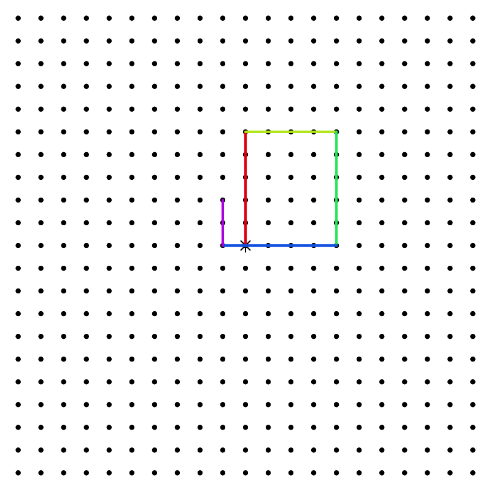

Describe the path taken by the turtle.

- North 5
- East 4
- South 5
- West 5
- North 2

A turtle starts at the star in the middle, facing North. While dragging markers, she walks forward for a while, then turns either to her right (clockwise) or to her left (counterclockwise) by 90°. She repeats this, starting with a red marker, until she has drawn 5 segments.

The distance between adjacent dots is 1 unit.

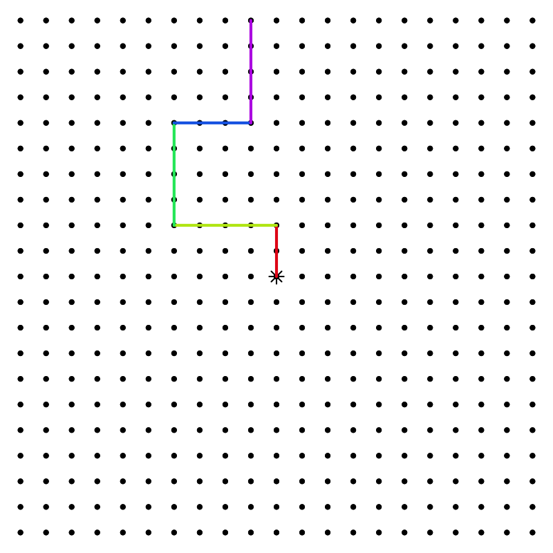

Describe the path taken by the turtle.

- Go
- Turn
- Go
- Turn
- Go
- Turn
- Go
- Turn
- Go
- Go 2
- Turn left
- Go 4
- Turn right
- Go 4
- Turn right
- Go 3
- Turn left
- Go 4

A turtle starts at the star in the middle, facing North. While dragging markers, she walks forward for a while, then turns either to her right (clockwise) or to her left (counterclockwise) by 90°. She repeats this, starting with a red marker, until she has drawn 5 segments.

The distance between adjacent dots is 1 unit.

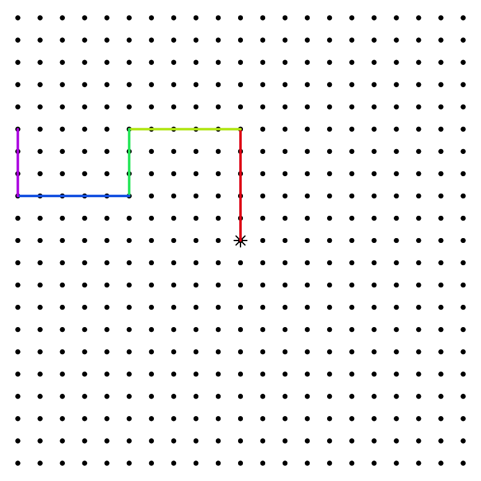

Describe the path taken by the turtle.

- Go
- Turn
- Go
- Turn
- Go
- Turn
- Go
- Turn
- Go
- Go 5
- Turn left
- Go 5
- Turn left
- Go 3
- Turn right
- Go 5
- Turn right
- Go 3

A turtle starts at the star in the middle, facing North. While dragging markers, she walks forward for a while, then turns either to her right (clockwise) or to her left (counterclockwise) by 90°. She repeats this, starting with a red marker, until she has drawn 5 segments.

The distance between adjacent dots is 1 unit.

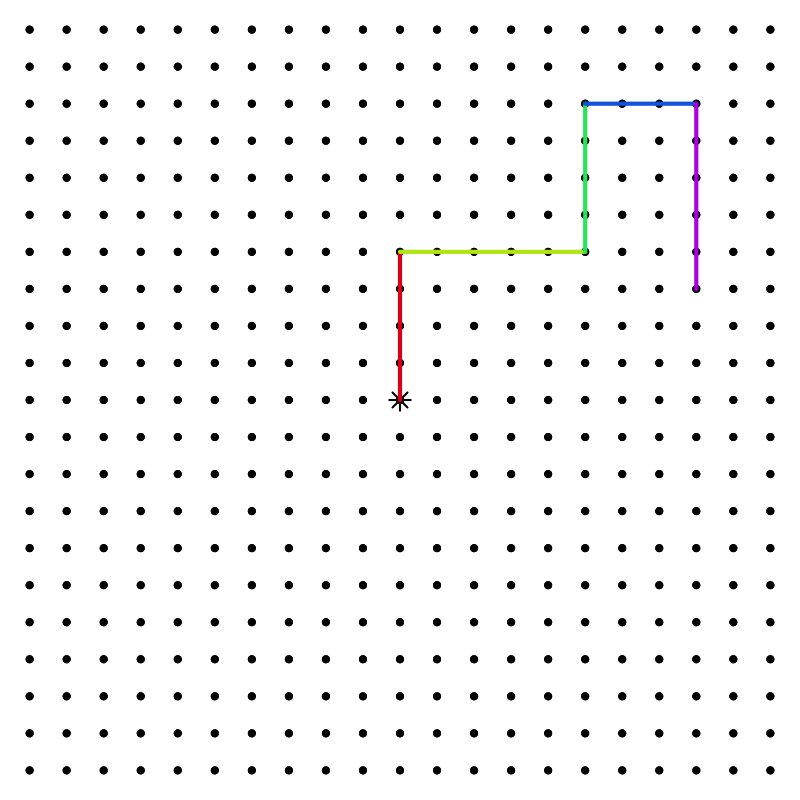

Describe the path taken by the turtle.

- Go
- Turn
- Go
- Turn
- Go
- Turn
- Go
- Turn
- Go
- Go 4
- Turn right
- Go 5
- Turn left
- Go 4
- Turn right
- Go 3
- Turn right
- Go 5

A turtle starts at the star in the middle, facing North. While dragging markers, she walks forward for a while, then turns either to her right (clockwise) or to her left (counterclockwise) by 90°. She repeats this, starting with a red marker, until she has drawn 5 segments.

The distance between adjacent dots is 1 unit.

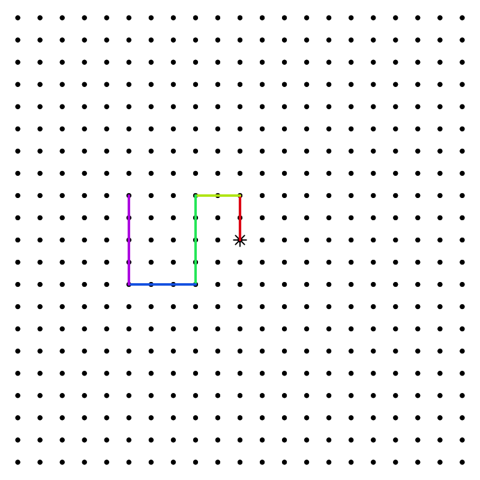

Describe the path taken by the turtle.

- Go
- Turn
- Go
- Turn
- Go
- Turn
- Go
- Turn
- Go
- Go 2
- Turn left
- Go 2
- Turn left
- Go 4
- Turn right
- Go 3
- Turn right
- Go 4

A turtle starts at the star in the middle, facing North. While dragging markers, she walks forward for a while, then turns either to her right (clockwise) or to her left (counterclockwise) by 90°. She repeats this, starting with a red marker, until she has drawn 5 segments.

The distance between adjacent dots is 1 unit.

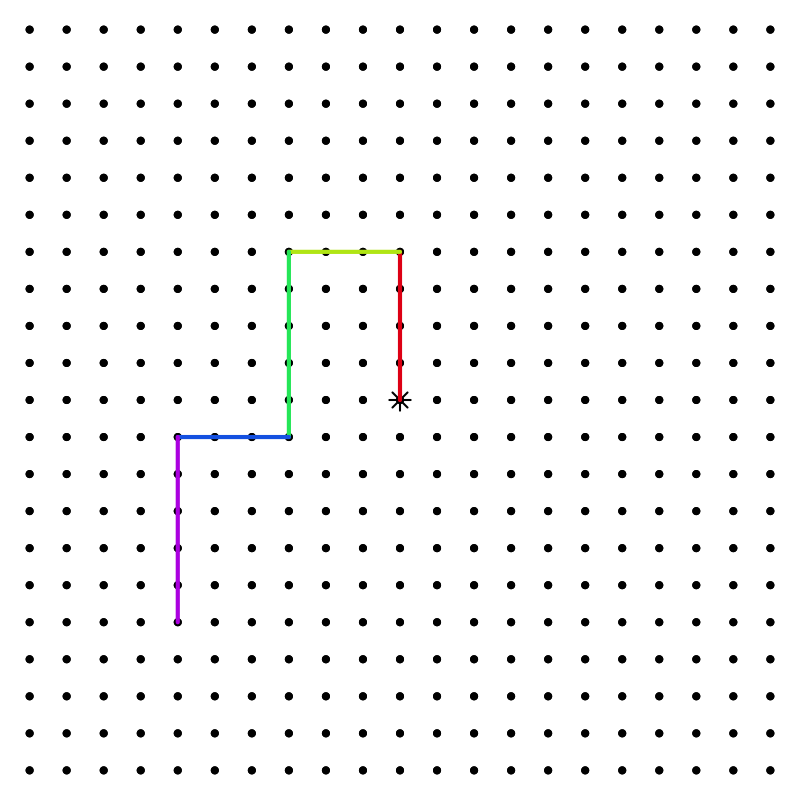

Describe the path taken by the turtle.

- Go
- Turn
- Go
- Turn
- Go
- Turn
- Go
- Turn
- Go
- Go 4
- Turn left
- Go 3
- Turn left
- Go 5
- Turn right
- Go 3
- Turn left
- Go 5

A turtle starts at the star in the middle, facing North. While dragging markers, she walks forward for a while, then turns either to her right (clockwise) or to her left (counterclockwise) by 90°. She repeats this, starting with a red marker, until she has drawn 5 segments.

The distance between adjacent dots is 1 unit.

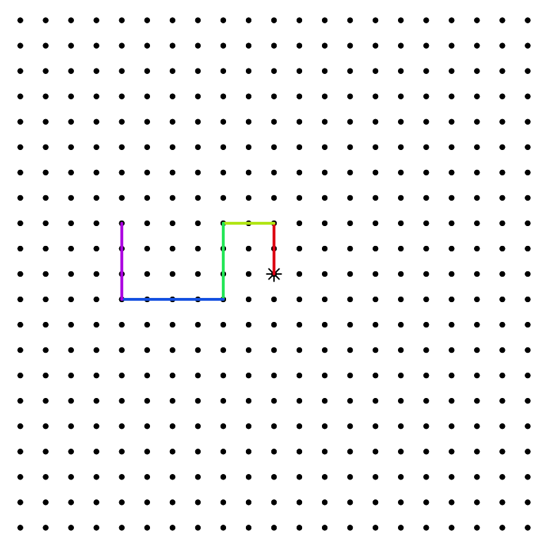

Describe the path taken by the turtle.

- Go
- Turn
- Go
- Turn
- Go
- Turn
- Go
- Turn
- Go
- Go 2
- Turn left
- Go 2
- Turn left
- Go 3
- Turn right
- Go 4
- Turn right
- Go 3

A turtle starts at the star in the middle, facing North. While dragging markers, she walks forward for a while, then turns either to her right (clockwise) or to her left (counterclockwise) by 90°. She repeats this, starting with a red marker, until she has drawn 5 segments.

The distance between adjacent dots is 1 unit.

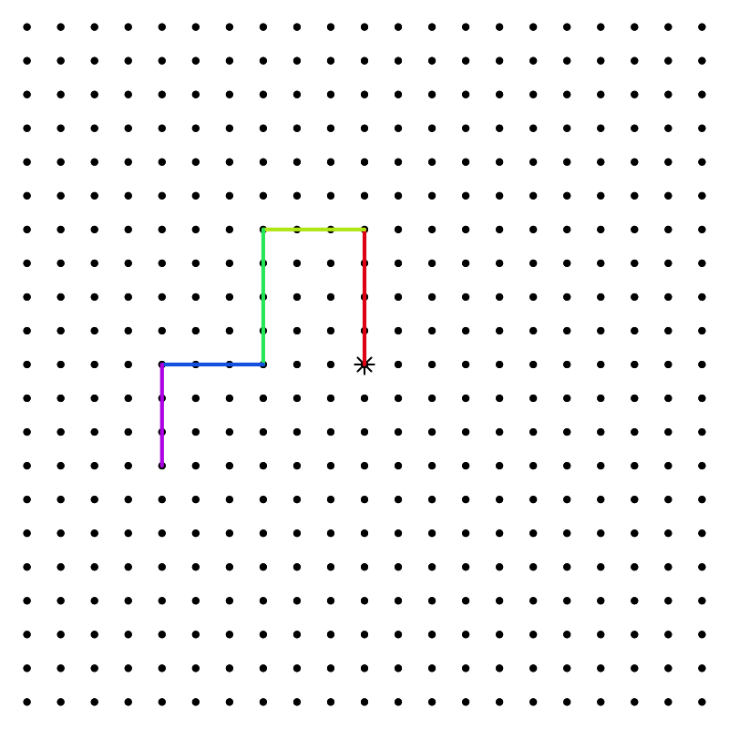

Describe the path taken by the turtle.

- Go
- Turn
- Go
- Turn
- Go
- Turn
- Go
- Turn
- Go
- Go 4
- Turn left
- Go 3
- Turn left
- Go 4
- Turn right
- Go 3
- Turn left
- Go 3

A turtle starts at the star in the middle, facing North. While dragging markers, she walks forward for a while, then turns either to her right (clockwise) or to her left (counterclockwise) by 90°. She repeats this, starting with a red marker, until she has drawn 5 segments.

The distance between adjacent dots is 1 unit.

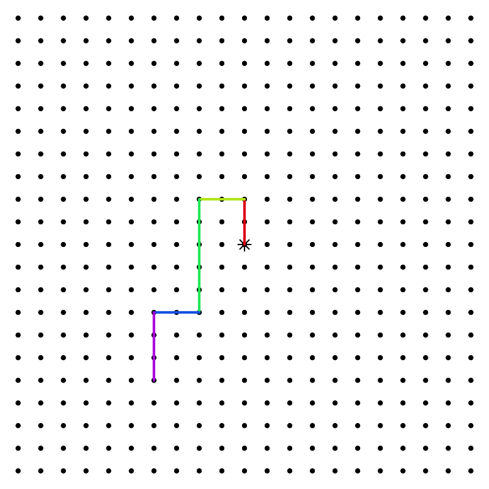

Describe the path taken by the turtle.

- Go
- Turn
- Go
- Turn
- Go
- Turn
- Go
- Turn
- Go
- Go 2
- Turn left
- Go 2
- Turn left
- Go 5
- Turn right
- Go 2
- Turn left
- Go 3

A turtle starts at the star in the middle, facing North. While dragging markers, she walks forward for a while, then turns either to her right (clockwise) or to her left (counterclockwise) by 90°. She repeats this, starting with a red marker, until she has drawn 5 segments.

The distance between adjacent dots is 1 unit.

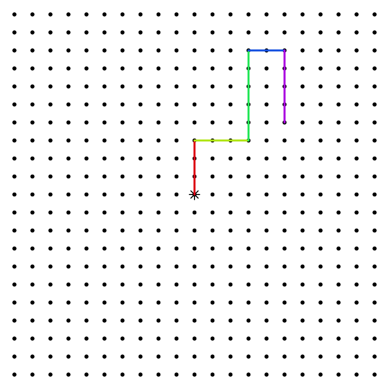

Describe the path taken by the turtle.

- Go
- Turn
- Go
- Turn
- Go
- Turn
- Go
- Turn
- Go
- Go 3
- Turn right
- Go 3
- Turn left
- Go 5
- Turn right
- Go 2
- Turn right
- Go 4

A turtle starts at the star in the middle, facing North. While dragging markers, she walks forward for a while, then turns either to her right (clockwise) or to her left (counterclockwise) by 90°. She repeats this, starting with a red marker, until she has drawn 5 segments.

The distance between adjacent dots is 1 unit.

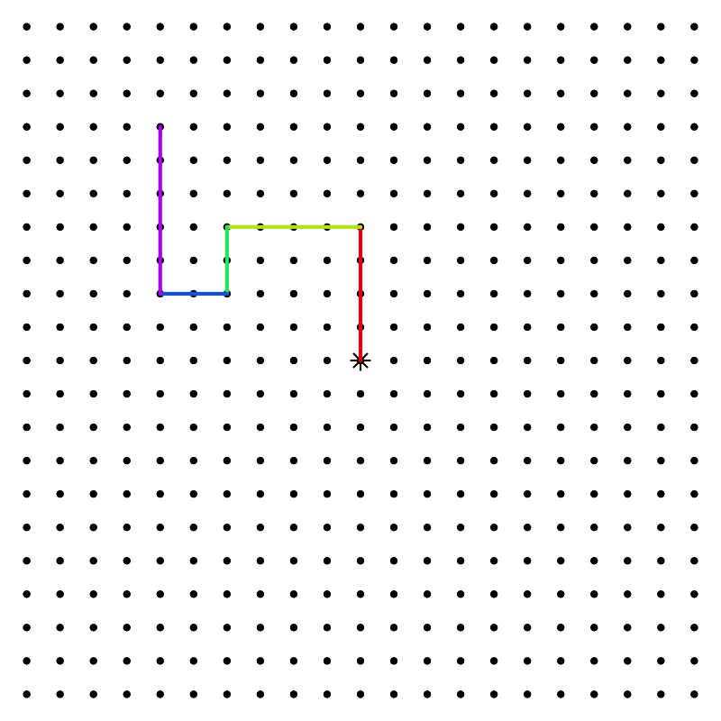

Describe the path taken by the turtle.

- Go
- Turn
- Go
- Turn
- Go
- Turn
- Go
- Turn
- Go
- Go 4
- Turn left
- Go 4
- Turn left
- Go 2
- Turn right
- Go 2
- Turn right
- Go 5

A turtle starts at the star in the middle, facing North. She walks forward for a while, then turns 60° either to her right (clockwise) or to her left (counterclockwise). She repeats this, marking her path with various colors, until she has drawn 6 segments.

The distance between adjacent dots is 1 unit.

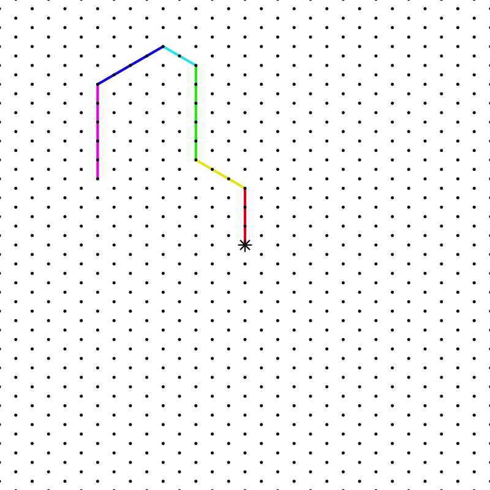

Describe the path taken by the turtle.

- Go
- Turn
- Go
- Turn
- Go
- Turn
- Go
- Turn
- Go
- Turn
- Go
- Go 3
- Turn left
- Go 3
- Turn right
- Go 5
- Turn left
- Go 2
- Turn left
- Go 4
- Turn left
- Go 5

A turtle starts at the star in the middle, facing North. She walks forward for a while, then turns 60° either to her right (clockwise) or to her left (counterclockwise). She repeats this, marking her path with various colors, until she has drawn 6 segments.

The distance between adjacent dots is 1 unit.

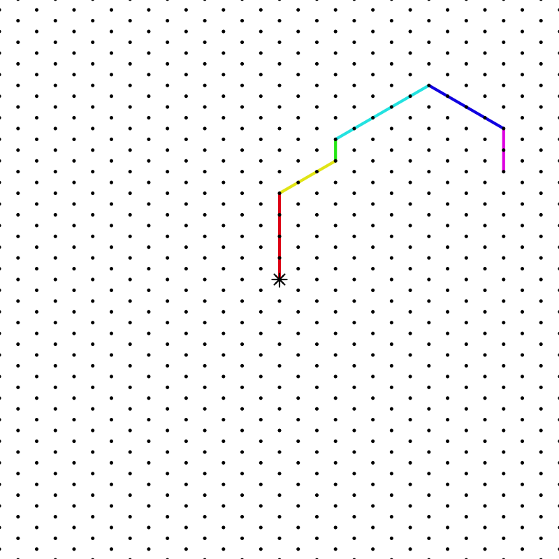

Describe the path taken by the turtle.

- Go
- Turn
- Go
- Turn
- Go
- Turn
- Go
- Turn
- Go
- Turn
- Go
- Go 4
- Turn right
- Go 3
- Turn left
- Go 1
- Turn right
- Go 5
- Turn right
- Go 4
- Turn right
- Go 2

A turtle starts at the star in the middle, facing North. She walks forward for a while, then turns 60° either to her right (clockwise) or to her left (counterclockwise). She repeats this, marking her path with various colors, until she has drawn 6 segments.

The distance between adjacent dots is 1 unit.

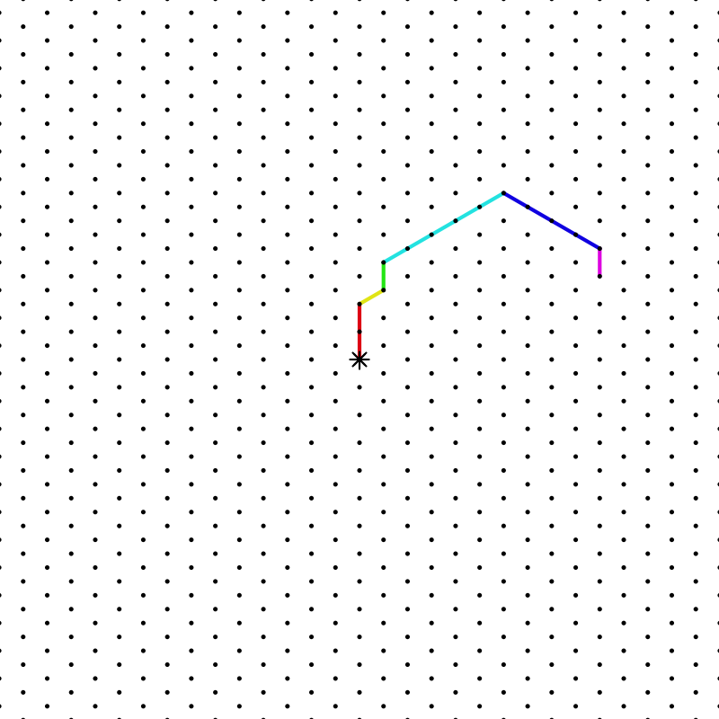

Describe the path taken by the turtle.

- Go
- Turn
- Go
- Turn
- Go
- Turn
- Go
- Turn
- Go
- Turn
- Go
- Go 2
- Turn right
- Go 1
- Turn left
- Go 1
- Turn right
- Go 5
- Turn right
- Go 4
- Turn right
- Go 1

A turtle starts at the star in the middle, facing North. She walks forward for a while, then turns 60° either to her right (clockwise) or to her left (counterclockwise). She repeats this, marking her path with various colors, until she has drawn 6 segments.

The distance between adjacent dots is 1 unit.

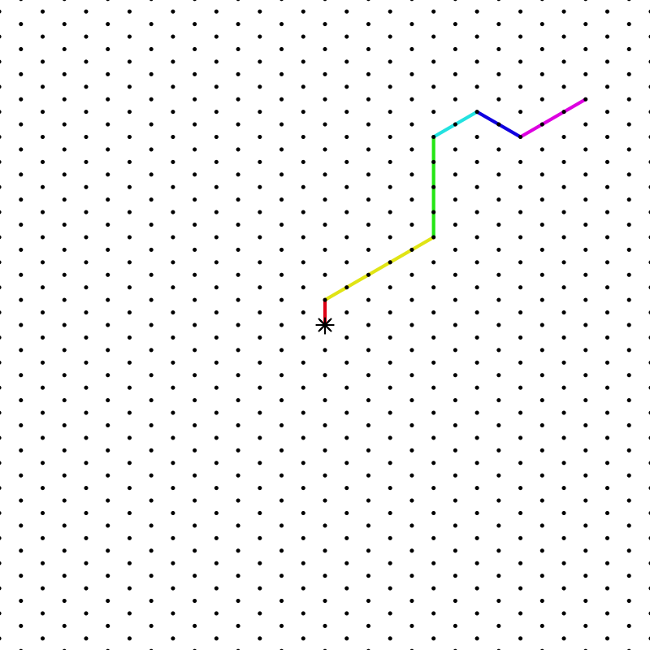

Describe the path taken by the turtle.

- Go
- Turn
- Go
- Turn
- Go
- Turn
- Go
- Turn
- Go
- Turn
- Go
- Go 1
- Turn right
- Go 5
- Turn left
- Go 4
- Turn right
- Go 2
- Turn right
- Go 2
- Turn left
- Go 3

A turtle starts at the star in the middle, facing North. She walks forward for a while, then turns 60° either to her right (clockwise) or to her left (counterclockwise). She repeats this, marking her path with various colors, until she has drawn 6 segments.

The distance between adjacent dots is 1 unit.

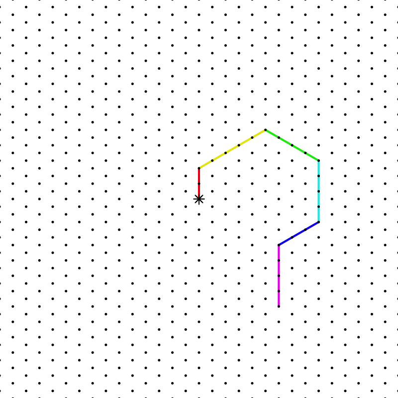

Describe the path taken by the turtle.

- Go
- Turn
- Go
- Turn
- Go
- Turn
- Go
- Turn
- Go
- Turn
- Go
- Go 2
- Turn right
- Go 5
- Turn right
- Go 4
- Turn right
- Go 4
- Turn right
- Go 3
- Turn left
- Go 4

A turtle starts at the star in the middle, facing North. She walks forward for a while, then turns 60° either to her right (clockwise) or to her left (counterclockwise). She repeats this, marking her path with various colors, until she has drawn 6 segments.

The distance between adjacent dots is 1 unit.

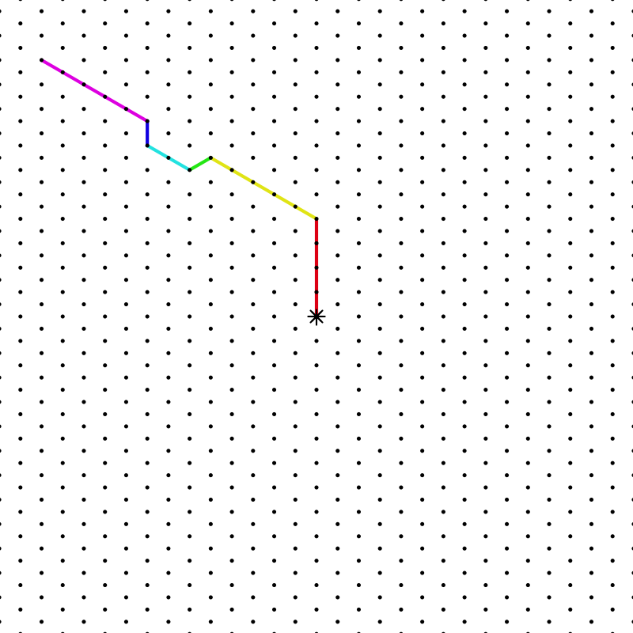

Describe the path taken by the turtle.

- Go
- Turn
- Go
- Turn
- Go
- Turn
- Go
- Turn
- Go
- Turn
- Go
- Go 4
- Turn left
- Go 5
- Turn left
- Go 1
- Turn right
- Go 2
- Turn right
- Go 1
- Turn left
- Go 5

A turtle starts at the star in the middle, facing North. She walks forward for a while, then turns 60° either to her right (clockwise) or to her left (counterclockwise). She repeats this, marking her path with various colors, until she has drawn 6 segments.

The distance between adjacent dots is 1 unit.

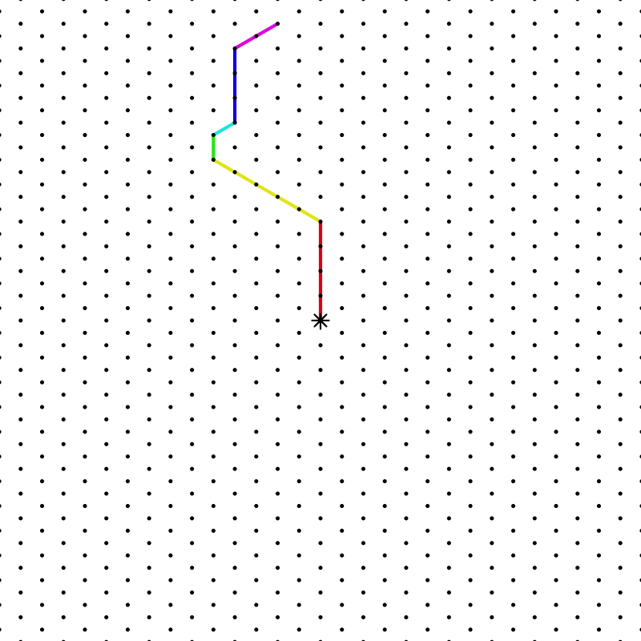

Describe the path taken by the turtle.

- Go
- Turn
- Go
- Turn
- Go
- Turn
- Go
- Turn
- Go
- Turn
- Go
- Go 4
- Turn left
- Go 5
- Turn right
- Go 1
- Turn right
- Go 1
- Turn left
- Go 3
- Turn right
- Go 2

A turtle starts at the star in the middle, facing North. She walks forward for a while, then turns 60° either to her right (clockwise) or to her left (counterclockwise). She repeats this, marking her path with various colors, until she has drawn 6 segments.

The distance between adjacent dots is 1 unit.

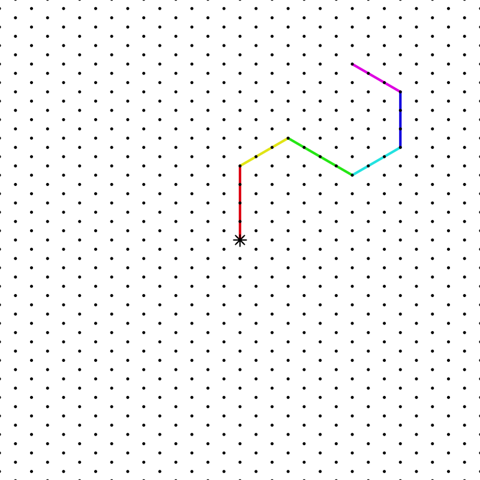

Describe the path taken by the turtle.

- Go
- Turn
- Go
- Turn
- Go
- Turn
- Go
- Turn
- Go
- Turn
- Go
- Go 4
- Turn right
- Go 3
- Turn right
- Go 4
- Turn left
- Go 3
- Turn left
- Go 3
- Turn left
- Go 3

A turtle starts at the star in the middle, facing North. She walks forward for a while, then turns 60° either to her right (clockwise) or to her left (counterclockwise). She repeats this, marking her path with various colors, until she has drawn 6 segments.

The distance between adjacent dots is 1 unit.

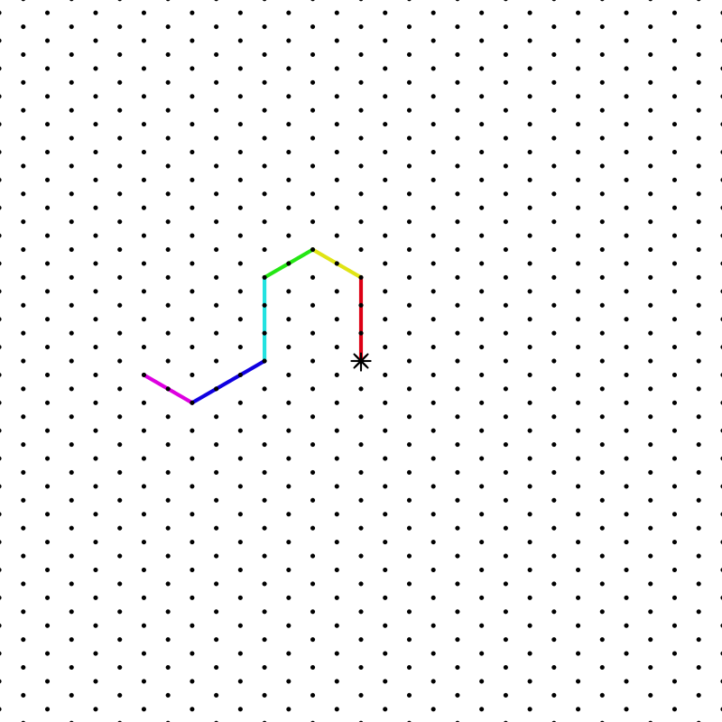

Describe the path taken by the turtle.

- Go
- Turn
- Go
- Turn
- Go
- Turn
- Go
- Turn
- Go
- Turn
- Go
- Go 3
- Turn left
- Go 2
- Turn left
- Go 2
- Turn left
- Go 3
- Turn right
- Go 3
- Turn right
- Go 2

A turtle starts at the star in the middle, facing North. She walks forward for a while, then turns 60° either to her right (clockwise) or to her left (counterclockwise). She repeats this, marking her path with various colors, until she has drawn 6 segments.

The distance between adjacent dots is 1 unit.

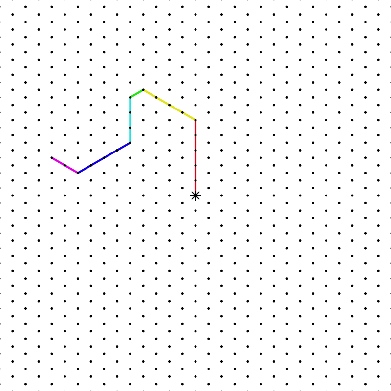

Describe the path taken by the turtle.

- Go
- Turn
- Go
- Turn
- Go
- Turn
- Go
- Turn
- Go
- Turn
- Go
- Go 5
- Turn left
- Go 4
- Turn left
- Go 1
- Turn left
- Go 3
- Turn right
- Go 4
- Turn right
- Go 2